# Project 1: Wrangling, Exploration, Visualization

SDS322E

## Data Wrangling, Exploration, Visualization

### Bao-Tran Nguyen, bnn428

#### Introduction

This project employ two datasets acquired from the website “https://vincentarelbundock.github.io/Rdatasets/datasets.html”, both of which explores the relationship between gender and their influence on employment aspects such as wages. The dataset, “ggs_wages,” contains wage data from the General Social Survey that took place from 1974 through 2018. This data was recorded to illustrate wage discrepancies by gender. This dataset contains many variable, such as respondent occupation, age, number of children, occupation prestige, marital status, work status, and education status. With many variables in this dataset, however, this project will primarily focus on “gender” (male/female), and their respective “income”.

These datasets and variables are interesting to me because gender inequality remains a prominent problem in our society today. I believe that there should not be a gender wage gap in the work place. Women and men should be earning the same amount of money for equal work. From these data sets, there is a chance for potential discrimination associations in terms of wage gaps. I suspect that there might be a wage gap between men and women in the second data set, demonstrating that men earns more money than women. This is, of course, just my personal hypothesis and is all speculation until proven accurate using data wrangling, exploration, visualization

```r
library(tidyverse)

wagegap <- read_csv("gss_wages.csv")

wage1 <- wagegap %>% select(1:6)
wage1
```

```
## # A tibble: 61,697 x 6
##       X1  year realrinc   age occ10 occrecode
##    <dbl> <dbl>    <dbl> <dbl> <dbl> <chr>
##  1     1  1974     4935    21  5620 Office and Administrative Support
##  2     2  1974    43178    41  2040 Professional
##  3     3  1974       NA    83    NA <NA>
##  4     4  1974       NA    69    NA <NA>
##  5     5  1974    18505    58  5820 Office and Administrative Support
##  6     6  1974    22206    30   910 Business/Finance
##  7     7  1974    55515    48   230 Business/Finance
##  8     8  1974       NA    67  6355 Construction/Extraction
##  9     9  1974       NA    51  4720 Sales
## 10    10  1974     4935    54  3940 Service
## # … with 61,687 more rows
```

```r
wage2 <- wagegap %>% select(1, 7:12)
wage2
```

```
## # A tibble: 61,697 x 7
##       X1 prestg10 childs wrkstat     gender educcat               maritalcat
##    <dbl>    <dbl>  <dbl> <chr>       <chr>  <chr>                 <chr>
##  1     1       25      0 School      Male   High School           Married
##  2     2       66      3 Full-Time   Male   Bachelor              Married
##  3     3       NA      2 Housekeeper Female Less Than High School Widowed
##  4     4       NA      2 Housekeeper Female Less Than High School Widowed
##  5     5       37      0 Full-Time   Female High School           Never Married
##  6     6       45      0 School      Male   Bachelor              Married
##  7     7       59      2 Full-Time   Male   Graduate              Married
##  8     8       49      1 Retired     Male   Less Than High School Married
##  9     9       28      2 Housekeeper Female High School           Married
## 10    10       38      2 Full-Time   Female Less Than High School Married
## # … with 61,687 more rows
```

*Due to some technical errors with my first data set, I was instructed by Dr.Woodward to split up my second data set and join them later by X1.*

#### Tidying: Reshaping

```r
# untidy
untidywagegap <- wagegap %>% pivot_wider(names_from = "gender",
    values_from = "age")
untidywagegap
```

```
## # A tibble: 61,697 x 12
##       X1  year realrinc occ10 occrecode prestg10 childs wrkstat educcat
##    <dbl> <dbl>    <dbl> <dbl> <chr>        <dbl>  <dbl> <chr>   <chr>
##  1     1  1974     4935  5620 Office a…       25      0 School  High S…
##  2     2  1974    43178  2040 Professi…       66      3 Full-T… Bachel…
##  3     3  1974       NA    NA <NA>            NA      2 Housek… Less T…
##  4     4  1974       NA    NA <NA>            NA      2 Housek… Less T…
##  5     5  1974    18505  5820 Office a…       37      0 Full-T… High S…
##  6     6  1974    22206   910 Business…       45      0 School  Bachel…
##  7     7  1974    55515   230 Business…       59      2 Full-T… Gradua…
##  8     8  1974       NA  6355 Construc…       49      1 Retired Less T…
##  9     9  1974       NA  4720 Sales           28      2 Housek… High S…
## 10    10  1974     4935  3940 Service         38      2 Full-T… Less T…
## # … with 61,687 more rows, and 3 more variables: maritalcat <chr>, Male <dbl>,
## #   Female <dbl>
```

```r
# tidy
tidywagegap <- untidywagegap %>% pivot_longer(11:12, names_to = "gender",
    values_to = "age", values_drop_na = T)
tidywagegap
```

```
## # A tibble: 61,478 x 12
##       X1  year realrinc occ10 occrecode prestg10 childs wrkstat educcat
##    <dbl> <dbl>    <dbl> <dbl> <chr>        <dbl>  <dbl> <chr>   <chr>
##  1     1  1974     4935  5620 Office a…       25      0 School  High S…
##  2     2  1974    43178  2040 Professi…       66      3 Full-T… Bachel…
##  3     3  1974       NA    NA <NA>            NA      2 Housek… Less T…
##  4     4  1974       NA    NA <NA>            NA      2 Housek… Less T…
##  5     5  1974    18505  5820 Office a…       37      0 Full-T… High S…
##  6     6  1974    22206   910 Business…       45      0 School  Bachel…
##  7     7  1974    55515   230 Business…       59      2 Full-T… Gradua…
##  8     8  1974       NA  6355 Construc…       49      1 Retired Less T…
##  9     9  1974       NA  4720 Sales           28      2 Housek… High S…
## 10    10  1974     4935  3940 Service         38      2 Full-T… Less T…
## # … with 61,468 more rows, and 3 more variables: maritalcat <chr>,
## #   gender <chr>, age <dbl>
```

```r
wagegap %>% summarize(sum(is.na(age)))
```

```
## # A tibble: 1 x 1
##   `sum(is.na(age))`
##               <int>
## 1               219
```

#### Joining/Merging

```r
# joining code
fulldata <- full_join(wage1, wage2, by = c(X1 = "X1"))

fulldata
```

```
## # A tibble: 61,697 x 12
##       X1  year realrinc   age occ10 occrecode prestg10 childs wrkstat gender
##    <dbl> <dbl>    <dbl> <dbl> <dbl> <chr>        <dbl>  <dbl> <chr>   <chr>
##  1     1  1974     4935    21  5620 Office a…       25      0 School  Male
##  2     2  1974    43178    41  2040 Professi…       66      3 Full-T… Male
##  3     3  1974       NA    83    NA <NA>            NA      2 Housek… Female
##  4     4  1974       NA    69    NA <NA>            NA      2 Housek… Female
##  5     5  1974    18505    58  5820 Office a…       37      0 Full-T… Female
##  6     6  1974    22206    30   910 Business…       45      0 School  Male
##  7     7  1974    55515    48   230 Business…       59      2 Full-T… Male
##  8     8  1974       NA    67  6355 Construc…       49      1 Retired Male
##  9     9  1974       NA    51  4720 Sales           28      2 Housek… Female
## 10    10  1974     4935    54  3940 Service         38      2 Full-T… Female
## # … with 61,687 more rows, and 2 more variables: educcat <chr>,
## #   maritalcat <chr>
```

```r
# total observations/rows in each dataset
glimpse(wage1)
```

```
## Rows: 61,697
## Columns: 6
## $ X1        <dbl> 1, 2, 3, 4, 5, 6, 7, 8, 9, 10, 11, 12, 13, 14, 15, 16, 17, …
## $ year      <dbl> 1974, 1974, 1974, 1974, 1974, 1974, 1974, 1974, 1974, 1974,…
## $ realrinc  <dbl> 4935, 43178, NA, NA, 18505, 22206, 55515, NA, NA, 4935, NA,…
## $ age       <dbl> 21, 41, 83, 69, 58, 30, 48, 67, 51, 54, 89, 71, 27, 30, 22,…
## $ occ10     <dbl> 5620, 2040, NA, NA, 5820, 910, 230, 6355, 4720, 3940, 4810,…
## $ occrecode <chr> "Office and Administrative Support", "Professional", NA, NA…
```

```r
glimpse(wage2)
```

```
## Rows: 61,697
## Columns: 7
## $ X1         <dbl> 1, 2, 3, 4, 5, 6, 7, 8, 9, 10, 11, 12, 13, 14, 15, 16, 17,…
## $ prestg10   <dbl> 25, 66, NA, NA, 37, 45, 59, 49, 28, 38, 47, 45, 50, 29, 33…
## $ childs     <dbl> 0, 3, 2, 2, 0, 0, 2, 1, 2, 2, 3, 1, 4, 3, 0, 1, 2, 3, 4, 8…
## $ wrkstat    <chr> "School", "Full-Time", "Housekeeper", "Housekeeper", "Full…
## $ gender     <chr> "Male", "Male", "Female", "Female", "Female", "Male", "Mal…
## $ educcat    <chr> "High School", "Bachelor", "Less Than High School", "Less …
## $ maritalcat <chr> "Married", "Married", "Widowed", "Widowed", "Never Married…
```

```r
glimpse(fulldata)
```

```
## Rows: 61,697
## Columns: 12
## $ X1         <dbl> 1, 2, 3, 4, 5, 6, 7, 8, 9, 10, 11, 12, 13, 14, 15, 16, 17,…
## $ year       <dbl> 1974, 1974, 1974, 1974, 1974, 1974, 1974, 1974, 1974, 1974…
## $ realrinc   <dbl> 4935, 43178, NA, NA, 18505, 22206, 55515, NA, NA, 4935, NA…
## $ age        <dbl> 21, 41, 83, 69, 58, 30, 48, 67, 51, 54, 89, 71, 27, 30, 22…
## $ occ10      <dbl> 5620, 2040, NA, NA, 5820, 910, 230, 6355, 4720, 3940, 4810…
## $ occrecode  <chr> "Office and Administrative Support", "Professional", NA, N…
## $ prestg10   <dbl> 25, 66, NA, NA, 37, 45, 59, 49, 28, 38, 47, 45, 50, 29, 33…
## $ childs     <dbl> 0, 3, 2, 2, 0, 0, 2, 1, 2, 2, 3, 1, 4, 3, 0, 1, 2, 3, 4, 8…
## $ wrkstat    <chr> "School", "Full-Time", "Housekeeper", "Housekeeper", "Full…
## $ gender     <chr> "Male", "Male", "Female", "Female", "Female", "Male", "Mal…
## $ educcat    <chr> "High School", "Bachelor", "Less Than High School", "Less …
## $ maritalcat <chr> "Married", "Married", "Widowed", "Widowed", "Never Married…
```

```r
# unique IDs in each dataset
glimpse(wage1)
```

```
## Rows: 61,697
## Columns: 6
## $ X1        <dbl> 1, 2, 3, 4, 5, 6, 7, 8, 9, 10, 11, 12, 13, 14, 15, 16, 17, …
## $ year      <dbl> 1974, 1974, 1974, 1974, 1974, 1974, 1974, 1974, 1974, 1974,…
## $ realrinc  <dbl> 4935, 43178, NA, NA, 18505, 22206, 55515, NA, NA, 4935, NA,…
## $ age       <dbl> 21, 41, 83, 69, 58, 30, 48, 67, 51, 54, 89, 71, 27, 30, 22,…
## $ occ10     <dbl> 5620, 2040, NA, NA, 5820, 910, 230, 6355, 4720, 3940, 4810,…
## $ occrecode <chr> "Office and Administrative Support", "Professional", NA, NA…
```

```r
glimpse(wage2)
```

```
## Rows: 61,697
## Columns: 7
## $ X1         <dbl> 1, 2, 3, 4, 5, 6, 7, 8, 9, 10, 11, 12, 13, 14, 15, 16, 17,…
## $ prestg10   <dbl> 25, 66, NA, NA, 37, 45, 59, 49, 28, 38, 47, 45, 50, 29, 33…
## $ childs     <dbl> 0, 3, 2, 2, 0, 0, 2, 1, 2, 2, 3, 1, 4, 3, 0, 1, 2, 3, 4, 8…
## $ wrkstat    <chr> "School", "Full-Time", "Housekeeper", "Housekeeper", "Full…
## $ gender     <chr> "Male", "Male", "Female", "Female", "Female", "Male", "Mal…
## $ educcat    <chr> "High School", "Bachelor", "Less Than High School", "Less …
## $ maritalcat <chr> "Married", "Married", "Widowed", "Widowed", "Never Married…
```

```r
## The number of people that are in `gensisc` but not in
## `wagegap`
nrow(anti_join(wage1, wage2, by = c(X1 = "X1")))
```

```
## [1] 0
```

```r
## The number of people that are in `wagegap` but not in
## `gendisc'
nrow(anti_join(wage1, wage2, by = c(X1 = "X1")))
```

```
## [1] 0
```

```r
## The number of people the two datasets have in common
nrow(inner_join(wage1, wage2, by = c(X1 = "X1")))
```

```
## [1] 61697
```

#### Wrangling

```r
# filter
fulldata %>% filter(gender == "Male" & realrinc > 15000)
```

```
## # A tibble: 12,844 x 12
##       X1  year realrinc   age occ10 occrecode prestg10 childs wrkstat gender
##    <dbl> <dbl>    <dbl> <dbl> <dbl> <chr>        <dbl>  <dbl> <chr>   <chr>
##  1     2  1974    43178    41  2040 Professi…       66      3 Full-T… Male
##  2     6  1974    22206    30   910 Business…       45      0 School  Male
##  3     7  1974    55515    48   230 Business…       59      2 Full-T… Male
##  4    16  1974    18505    23  7810 Producti…       28      1 Full-T… Male
##  5    26  1974    30841    59  4710 Sales           48      1 Full-T… Male
##  6    27  1974    30841    53  4760 Sales           31      4 Full-T… Male
##  7    31  1974    96450    51   430 Business…       39      2 Full-T… Male
##  8    37  1974    43178    39  7700 Producti…       50      4 Full-T… Male
##  9    41  1974    30841    28    10 Business…       72      1 Full-T… Male
## 10    42  1974    22206    47  2320 Professi…       64      0 Full-T… Male
## # … with 12,834 more rows, and 2 more variables: educcat <chr>,
## #   maritalcat <chr>
```

```r
fulldata %>% filter(gender == "Female" & realrinc > 15000)
```

```
## # A tibble: 7,665 x 12
##       X1  year realrinc   age occ10 occrecode prestg10 childs wrkstat gender
##    <dbl> <dbl>    <dbl> <dbl> <dbl> <chr>        <dbl>  <dbl> <chr>   <chr>
##  1     5  1974    18505    58  5820 Office a…       37      0 Full-T… Female
##  2    40  1974    30841    23  2320 Professi…       64      0 Full-T… Female
##  3    45  1974    16038    50  5700 Office a…       47      3 Full-T… Female
##  4    55  1974    30841    52  2850 Professi…       67      1 Full-T… Female
##  5    60  1974    30841    55  4010 Service         38      1 Full-T… Female
##  6    70  1974    30841    29  2630 Professi…       46      1 Full-T… Female
##  7   110  1974    22206    44  3600 Service         48      4 Full-T… Female
##  8   119  1974    22206    27  2310 Professi…       61      0 Full-T… Female
##  9   135  1974    16038    30  5160 Office a…       39      0 Full-T… Female
## 10   150  1974    22206    43   230 Business…       59      2 Full-T… Female
## # … with 7,655 more rows, and 2 more variables: educcat <chr>, maritalcat <chr>
```

```r
# count
fulldata %>% count(educcat)
```

```
## # A tibble: 6 x 2
##   educcat                   n
##   <chr>                 <int>
## 1 Bachelor               9219
## 2 Graduate               4599
## 3 High School           31713
## 4 Junior College         3631
## 5 Less Than High School 12400
## 6 <NA>                    135
```

```r
fulldata %>% count(gender == "Female")  #34591
```

```
## # A tibble: 2 x 2
##   `gender == "Female"`     n
##   <lgl>                <int>
## 1 FALSE                27106
## 2 TRUE                 34591
```

```r
fulldata %>% count(gender == "Male")  #27106\t
```

```
## # A tibble: 2 x 2
##   `gender == "Male"`     n
##   <lgl>              <int>
## 1 FALSE              34591
## 2 TRUE               27106
```

```r
fulldata %>% filter(gender == "Female") %>% count(educcat ==
    "Bachelor" | educcat == "Graduate")
```

```
## # A tibble: 3 x 2
##   `educcat == "Bachelor" | educcat == "Graduate"`     n
##   <lgl>                                           <int>
## 1 FALSE                                           27417
## 2 TRUE                                             7095
## 3 NA                                                 79
```

```r
# (7095/34591)*100 = 20.5%
fulldata %>% filter(gender == "Male") %>% count(educcat == "Bachelor" |
    educcat == "Graduate")
```

```
## # A tibble: 3 x 2
##   `educcat == "Bachelor" | educcat == "Graduate"`     n
##   <lgl>                                           <int>
## 1 FALSE                                           20327
## 2 TRUE                                             6723
## 3 NA                                                 56
```

```r
# (6723/27106)*100 = 24.8%

# arrange
fulldata %>% arrange(educcat)
```

```
## # A tibble: 61,697 x 12
##       X1  year realrinc   age occ10 occrecode prestg10 childs wrkstat gender
##    <dbl> <dbl>    <dbl> <dbl> <dbl> <chr>        <dbl>  <dbl> <chr>   <chr>
##  1     2  1974    43178    41  2040 Professi…       66      3 Full-T… Male
##  2     6  1974    22206    30   910 Business…       45      0 School  Male
##  3    40  1974    30841    23  2320 Professi…       64      0 Full-T… Female
##  4    41  1974    30841    28    10 Business…       72      1 Full-T… Male
##  5    46  1974    30841    32  9620 Transpor…       25      2 Full-T… Male
##  6    66  1974       NA    24    NA <NA>            NA      0 School  Male
##  7    69  1974       NA    29    NA <NA>            NA      2 Housek… Female
##  8    70  1974    30841    29  2630 Professi…       46      1 Full-T… Female
##  9    87  1974    11103    58   205 Business…       46      4 Tempor… Male
## 10    90  1974     4935    29  3255 Professi…       64      2 Part-T… Female
## # … with 61,687 more rows, and 2 more variables: educcat <chr>,
## #   maritalcat <chr>
```

```r
fulldata %>% arrange(desc(realrinc))
```

```
## # A tibble: 61,697 x 12
##       X1  year realrinc   age occ10 occrecode prestg10 childs wrkstat gender
##    <dbl> <dbl>    <dbl> <dbl> <dbl> <chr>        <dbl>  <dbl> <chr>   <chr>
##  1 47922  2008  480144.    36   840 Business…       58      0 Full-T… Male
##  2 47931  2008  480144.    42   800 Business…       60      0 Full-T… Male
##  3 47955  2008  480144.    34  4920 Sales           49      2 Part-T… Female
##  4 47993  2008  480144.    43  4820 Sales           58      2 Full-T… Male
##  5 47997  2008  480144.    57  2750 Professi…       51      2 Full-T… Male
##  6 48023  2008  480144.    62    10 Business…       72      2 Full-T… Female
##  7 48156  2008  480144.    42  1530 Professi…       70      3 Full-T… Male
##  8 48161  2008  480144.    43   110 Business…       60      1 Full-T… Male
##  9 48173  2008  480144.    41   710 Business…       51      2 Full-T… Male
## 10 48175  2008  480144.    36    10 Business…       72      2 Full-T… Male
## # … with 61,687 more rows, and 2 more variables: educcat <chr>,
## #   maritalcat <chr>
```

```r
# select
fulldata %>% select(gender, educcat)
```

```
## # A tibble: 61,697 x 2
##    gender educcat
##    <chr>  <chr>
##  1 Male   High School
##  2 Male   Bachelor
##  3 Female Less Than High School
##  4 Female Less Than High School
##  5 Female High School
##  6 Male   Bachelor
##  7 Male   Graduate
##  8 Male   Less Than High School
##  9 Female High School
## 10 Female Less Than High School
## # … with 61,687 more rows
```

```r
fulldata %>% select(gender, realrinc) %>% na.omit()
```

```
## # A tibble: 37,887 x 2
##    gender realrinc
##    <chr>     <dbl>
##  1 Male       4935
##  2 Male      43178
##  3 Female    18505
##  4 Male      22206
##  5 Male      55515
##  6 Female     4935
##  7 Female     4935
##  8 Male      18505
##  9 Male      11103
## 10 Male      30841
## # … with 37,877 more rows
```

```r
# group by
fulldata %>% group_by(gender)
```

```
## # A tibble: 61,697 x 12
## # Groups:   gender [2]
##       X1  year realrinc   age occ10 occrecode prestg10 childs wrkstat gender
##    <dbl> <dbl>    <dbl> <dbl> <dbl> <chr>        <dbl>  <dbl> <chr>   <chr>
##  1     1  1974     4935    21  5620 Office a…       25      0 School  Male
##  2     2  1974    43178    41  2040 Professi…       66      3 Full-T… Male
##  3     3  1974       NA    83    NA <NA>            NA      2 Housek… Female
##  4     4  1974       NA    69    NA <NA>            NA      2 Housek… Female
##  5     5  1974    18505    58  5820 Office a…       37      0 Full-T… Female
##  6     6  1974    22206    30   910 Business…       45      0 School  Male
##  7     7  1974    55515    48   230 Business…       59      2 Full-T… Male
##  8     8  1974       NA    67  6355 Construc…       49      1 Retired Male
##  9     9  1974       NA    51  4720 Sales           28      2 Housek… Female
## 10    10  1974     4935    54  3940 Service         38      2 Full-T… Female
## # … with 61,687 more rows, and 2 more variables: educcat <chr>,
## #   maritalcat <chr>
```

```r
fulldata %>% group_by(educcat)
```

```
## # A tibble: 61,697 x 12
## # Groups:   educcat [6]
##       X1  year realrinc   age occ10 occrecode prestg10 childs wrkstat gender
##    <dbl> <dbl>    <dbl> <dbl> <dbl> <chr>        <dbl>  <dbl> <chr>   <chr>
##  1     1  1974     4935    21  5620 Office a…       25      0 School  Male
##  2     2  1974    43178    41  2040 Professi…       66      3 Full-T… Male
##  3     3  1974       NA    83    NA <NA>            NA      2 Housek… Female
##  4     4  1974       NA    69    NA <NA>            NA      2 Housek… Female
##  5     5  1974    18505    58  5820 Office a…       37      0 Full-T… Female
##  6     6  1974    22206    30   910 Business…       45      0 School  Male
##  7     7  1974    55515    48   230 Business…       59      2 Full-T… Male
##  8     8  1974       NA    67  6355 Construc…       49      1 Retired Male
##  9     9  1974       NA    51  4720 Sales           28      2 Housek… Female
## 10    10  1974     4935    54  3940 Service         38      2 Full-T… Female
## # … with 61,687 more rows, and 2 more variables: educcat <chr>,
## #   maritalcat <chr>
```

```r
# mutate
money_prestige <- fulldata %>% select(realrinc, prestg10)

fulldata <- fulldata %>% mutate(money_prestige, salary_per_prestige = realrinc/prestg10)

fulldata %>% select(realrinc, prestg10, salary_per_prestige) %>%
    na.omit() %>% arrange(desc(prestg10))
```

```
## # A tibble: 37,368 x 3
##    realrinc prestg10 salary_per_prestige
##       <dbl>    <dbl>               <dbl>
##  1    96450       80              1206.
##  2    55515       80               694.
##  3    22206       80               278.
##  4    81652       80              1021.
##  5    81652       80              1021.
##  6    72229       80               903.
##  7   201640       80              2520.
##  8   135131       80              1689.
##  9      905       80                11.3
## 10   135131       80              1689.
## # … with 37,358 more rows
```

```r
fulldata %>% mutate_if(is.numeric, round) %>% arrange(desc(realrinc))
```

```
## # A tibble: 61,697 x 13
##       X1  year realrinc   age occ10 occrecode prestg10 childs wrkstat gender
##    <dbl> <dbl>    <dbl> <dbl> <dbl> <chr>        <dbl>  <dbl> <chr>   <chr>
##  1 47922  2008   480144    36   840 Business…       58      0 Full-T… Male
##  2 47931  2008   480144    42   800 Business…       60      0 Full-T… Male
##  3 47955  2008   480144    34  4920 Sales           49      2 Part-T… Female
##  4 47993  2008   480144    43  4820 Sales           58      2 Full-T… Male
##  5 47997  2008   480144    57  2750 Professi…       51      2 Full-T… Male
##  6 48023  2008   480144    62    10 Business…       72      2 Full-T… Female
##  7 48156  2008   480144    42  1530 Professi…       70      3 Full-T… Male
##  8 48161  2008   480144    43   110 Business…       60      1 Full-T… Male
##  9 48173  2008   480144    41   710 Business…       51      2 Full-T… Male
## 10 48175  2008   480144    36    10 Business…       72      2 Full-T… Male
## # … with 61,687 more rows, and 3 more variables: educcat <chr>,
## #   maritalcat <chr>, salary_per_prestige <dbl>
```

```r
# summarize
fulldata %>% summarize_if(is.numeric, mean, na.rm = T)
```

```
## # A tibble: 1 x 8
##      X1  year realrinc   age occ10 prestg10 childs salary_per_prestige
##   <dbl> <dbl>    <dbl> <dbl> <dbl>    <dbl>  <dbl>               <dbl>
## 1 30849 1996.   22326.  46.2 4696.     43.1   1.92                499.
```

```r
fulldata %>% summarize_all(mean, na.rm = T)
```

```
## # A tibble: 1 x 13
##      X1  year realrinc   age occ10 occrecode prestg10 childs wrkstat gender
##   <dbl> <dbl>    <dbl> <dbl> <dbl>     <dbl>    <dbl>  <dbl>   <dbl>  <dbl>
## 1 30849 1996.   22326.  46.2 4696.        NA     43.1   1.92      NA     NA
## # … with 3 more variables: educcat <dbl>, maritalcat <dbl>,
## #   salary_per_prestige <dbl>
```

```r
fulldata %>% filter(gender == "Female") %>% summarize_all(mean,
    na.rm = T)  #16029.75
```

```
## # A tibble: 1 x 13
##       X1  year realrinc   age occ10 occrecode prestg10 childs wrkstat gender
##    <dbl> <dbl>    <dbl> <dbl> <dbl>     <dbl>    <dbl>  <dbl>   <dbl>  <dbl>
## 1 30706. 1996.   16030.  46.7 4433.        NA     42.5   2.05      NA     NA
## # … with 3 more variables: educcat <dbl>, maritalcat <dbl>,
## #   salary_per_prestige <dbl>
```

```r
fulldata %>% filter(gender == "Male") %>% summarize_all(mean,
    na.rm = T)  #28504.11
```

```
## # A tibble: 1 x 13
##       X1  year realrinc   age occ10 occrecode prestg10 childs wrkstat gender
##    <dbl> <dbl>    <dbl> <dbl> <dbl>     <dbl>    <dbl>  <dbl>   <dbl>  <dbl>
## 1 31032. 1996.   28504.  45.5 5012.        NA     43.7   1.76      NA     NA
## # … with 3 more variables: educcat <dbl>, maritalcat <dbl>,
## #   salary_per_prestige <dbl>
```

```r
fulldata %>% summarize_all(sd, na.rm = T)
```

```
## # A tibble: 1 x 13
##       X1  year realrinc   age occ10 occrecode prestg10 childs wrkstat gender
##    <dbl> <dbl>    <dbl> <dbl> <dbl>     <dbl>    <dbl>  <dbl>   <dbl>  <dbl>
## 1 17811.  12.8   28582.  17.6 2628.        NA     13.0   1.76      NA     NA
## # … with 3 more variables: educcat <dbl>, maritalcat <dbl>,
## #   salary_per_prestige <dbl>
```

```r
### summary stats for income
table1 <- fulldata %>% group_by(gender) %>% summarise(mean_inc = mean(realrinc,
    na.rm = T), sd_inc = sd(realrinc, na.rm = T), lowest_inc = min(realrinc,
    na.rm = T), highest_inc = max(realrinc, na.rm = T), IQR_inc = IQR(realrinc,
    na.rm = T)) %>% na.omit()
table1
```

```
## # A tibble: 2 x 6
##   gender mean_inc sd_inc lowest_inc highest_inc IQR_inc
##   <chr>     <dbl>  <dbl>      <dbl>       <dbl>   <dbl>
## 1 Female   16030. 19449.        227     480144.  15036.
## 2 Male     28504. 34209.        227     480144.  21044.
```

```r
### summary stats for prestige
table2 <- fulldata %>% group_by(gender) %>% summarise(mean_pres = mean(prestg10,
    na.rm = T), sd_pres = sd(prestg10, na.rm = T), lowest_pres = min(prestg10,
    na.rm = T), highest_pres = max(prestg10, na.rm = T), IQR_pres = IQR(prestg10,
    na.rm = T)) %>% na.omit()
table2
```

```
## # A tibble: 2 x 6
##   gender mean_pres sd_pres lowest_pres highest_pres IQR_pres
##   <chr>      <dbl>   <dbl>       <dbl>        <dbl>    <dbl>
## 1 Female      42.5    12.8          16           80       17
## 2 Male        43.7    13.2          16           80       15
```

```r
### summary stats for age
table3 <- fulldata %>% group_by(gender) %>% summarise(mean_age = mean(age,
    na.rm = T), sd_age = sd(age, na.rm = T), lowest_age = min(age,
    na.rm = T), highest_age = max(age, na.rm = T), IQR_age = IQR(age,
    na.rm = T)) %>% na.omit()
table3
```

```
## # A tibble: 2 x 6
##   gender mean_age sd_age lowest_age highest_age IQR_age
##   <chr>     <dbl>  <dbl>      <dbl>       <dbl>   <dbl>
## 1 Female     46.7   17.9         18          89      28
## 2 Male       45.5   17.1         18          89      27
```

```r
## summary stats for number of children
table4 <- fulldata %>% group_by(gender) %>% summarise(mean_child = mean(childs,
    na.rm = T), sd_child = sd(childs, na.rm = T), lowest_child = min(childs,
    na.rm = T), highest_child = max(childs, na.rm = T), IQR_chil = IQR(childs,
    na.rm = T)) %>% na.omit()
table4
```

```
## # A tibble: 2 x 6
##   gender mean_child sd_child lowest_child highest_child IQR_chil
##   <chr>       <dbl>    <dbl>        <dbl>         <dbl>    <dbl>
## 1 Female       2.05     1.77            0             8        2
## 2 Male         1.76     1.75            0             8        3
```

```r
## stringr
library(tidyverse)

string1 <- "From the 61,697 people in the study, the mean income for female was $16029 and the mean income for male was $28504. The lowest amount of income from the study is $227, and the highest income was $480144"

str_match_all(string1, "\\d+")
```

```
## [[1]]
##      [,1]
## [1,] "61"
## [2,] "697"
## [3,] "16029"
## [4,] "28504"
## [5,] "227"
## [6,] "480144"
```

```r
## Summarize after grouping by a categorical variable
fulldata %>% group_by(gender) %>% summarize(realrinc) %>% arrange(realrinc)
```

```
## # A tibble: 61,697 x 2
## # Groups:   gender [2]
##    gender realrinc
##    <chr>     <dbl>
##  1 Female      227
##  2 Female      227
##  3 Female      227
##  4 Female      227
##  5 Female      227
##  6 Female      227
##  7 Female      227
##  8 Female      227
##  9 Female      227
## 10 Female      227
## # … with 61,687 more rows
```

```r
fulldata %>% group_by(educcat) %>% summarize(realrinc) %>% arrange(desc(realrinc))
```

```
## # A tibble: 61,697 x 2
## # Groups:   educcat [6]
##    educcat  realrinc
##    <chr>       <dbl>
##  1 Bachelor  480144.
##  2 Bachelor  480144.
##  3 Bachelor  480144.
##  4 Bachelor  480144.
##  5 Bachelor  480144.
##  6 Bachelor  480144.
##  7 Bachelor  480144.
##  8 Bachelor  480144.
##  9 Bachelor  480144.
## 10 Graduate  480144.
## # … with 61,687 more rows
```

```r
## function inside summarize/ number of missing NA
num_NA <- function(x) {
    sum(is.na(x))
}

prop_NA <- function(x) {
    mean(is.na(x))
}

num_NA <- summarize_all(fulldata, num_NA)
num_NA
```

```
## # A tibble: 1 x 13
##      X1  year realrinc   age occ10 occrecode prestg10 childs wrkstat gender
##   <int> <int>    <int> <int> <int>     <int>    <int>  <int>   <int>  <int>
## 1     0     0    23810   219  3561      3561     4186    189      21      0
## # … with 3 more variables: educcat <int>, maritalcat <int>,
## #   salary_per_prestige <int>
```

```r
prop_NA <- summarize_all(fulldata, prop_NA)
prop_NA
```

```
## # A tibble: 1 x 13
##      X1  year realrinc     age  occ10 occrecode prestg10  childs wrkstat gender
##   <dbl> <dbl>    <dbl>   <dbl>  <dbl>     <dbl>    <dbl>   <dbl>   <dbl>  <dbl>
## 1     0     0    0.386 0.00355 0.0577    0.0577   0.0678 0.00306 3.40e-4      0
## # … with 3 more variables: educcat <dbl>, maritalcat <dbl>,
## #   salary_per_prestige <dbl>
```

```r
## Table of counts for each categorical variables (summary
## statistics)
fulldata %>% group_by() %>% summarise(n())
```

```
## # A tibble: 1 x 1
##   `n()`
##   <int>
## 1 61697
```

```r
fulldata %>% summarize_all(n_distinct)
```

```
## # A tibble: 1 x 13
##      X1  year realrinc   age occ10 occrecode prestg10 childs wrkstat gender
##   <int> <int>    <int> <int> <int>     <int>    <int>  <int>   <int>  <int>
## 1 61697    30      603    73   539        12       62     10       9      2
## # … with 3 more variables: educcat <int>, maritalcat <int>,
## #   salary_per_prestige <int>
```

```r
## Table with gt
library(gt)

table1 %>% gt %>% tab_header(title = md("**Summary Statistics**"),
    subtitle = md("A table of my summary statistics for income"))
```

**Summary Statistics**

A table of my summary statistics for income

| gender | mean_inc | sd_inc | lowest_inc | highest_inc | IQR_inc |
| --- | --- | --- | --- | --- | --- |
| Female | 16029.75 | 19449.12 | 227 | 480144.5 | 15035.62 |
| Male | 28504.11 | 34209.12 | 227 | 480144.5 | 21044.38 |

Upon wrangling the joined data, the findings/results did not differ significantly from my original hypothesis. In filtering the data by gender and annual income, I was able to find out the amount of people from both genders make above the minimum wage, using Texas minimum wage of $15,000 a year as reference. More people who identify as male (12,844) earned more than Texas minimum wage compared to that of females (7,665). Next, I wanted to wrangle the data to find out if there are more males persuing higher education/degrees than that of females, and how that would correlate with the mean income from both genders. To do so, I used the filter and count dplyr functions to generate my targeted summary statistics. In doing so, I found that there are, in fact, higher proportion of males with higher degrees than that of females. In this data set, there only 20.5% of females have a degree of ‘Bachelor’ or ‘Graduate’, while males have a 24.8% of having a degree of ‘Bachelor’ or ‘Graduate’. Using the dyplr functions filter and summarize_all, I was able to filter by gender and find out the mean income of both genders: $16029.7 for Female and $28504.11 for Male. This summary statistic is also shown later on when I compute the summary statistic tables.

Using the dyplr function ‘summarize’, I was able to make summary statistics tables of different variables. Table1 demonstrates that the mean income of Males is higher than that of Females. Table2 demonstrates when looking at job prestigious scores, Males has lightly higher job prestigious with a mean score of 43.73375 in comparison to Female’s prestigious job score of 42.50235. Table3 demonstrates the summary statistics for the age of Females and Males, with Females having the mean age of 46.7 and Males with the mean age of 45.48. Finally, table4 demonstrates the summary statistics for the number of children that each respective gender has, with Females having a mean number of children of 2.05 and Males with 1.76. These numbers, while representative of this data, are not 100% accurate as I ommited the NAs in the data set. In using creating my own function and using it inside summarize, I was able to compute the amount and proportion of missing NAs in the data set, as shown above in num_NA and prop_NA, respectively.

#### Visualizing

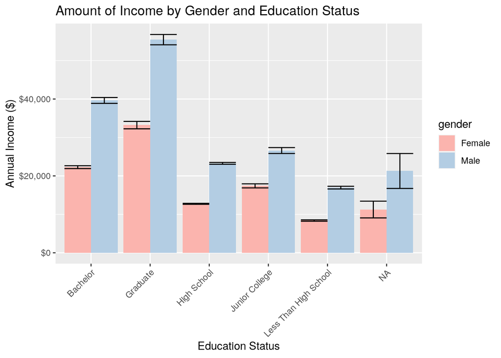

```r
# Plot 1

ggplot(fulldata, aes(x = educcat, y = realrinc, fill = gender)) +
    geom_bar(stat = "summary", fun = mean, position = "dodge") +
    geom_errorbar(stat = "summary", fun.data = mean_se, position = "dodge") +
    theme(axis.text.x = element_text(angle = 45, hjust = 1)) +
    scale_fill_brewer(palette = "Pastel1") + labs(x = "Education Status",
    y = "Annual Income ($)") + ggtitle("Amount of Income by Gender and Education Status") +
    scale_y_continuous(labels = scales::dollar)
```

Discussion of Plot 1

*In this bar graph, it is shown that across all education status, Male has higher income compared to Female. In addition, the plot depicts that the higher the education status, the higher the income of both genders. People holding Graduate level and Bachelor level degrees make more money than those who did not pursue higher education. In terms of error bars, omitting the data from the NA Education status, it seems that there is most error variation for Males with Graduate degrees in terms of income. All in all, when looking at gender and income alone, it is apparent that there is, in fact, a wage gap between both genders.*

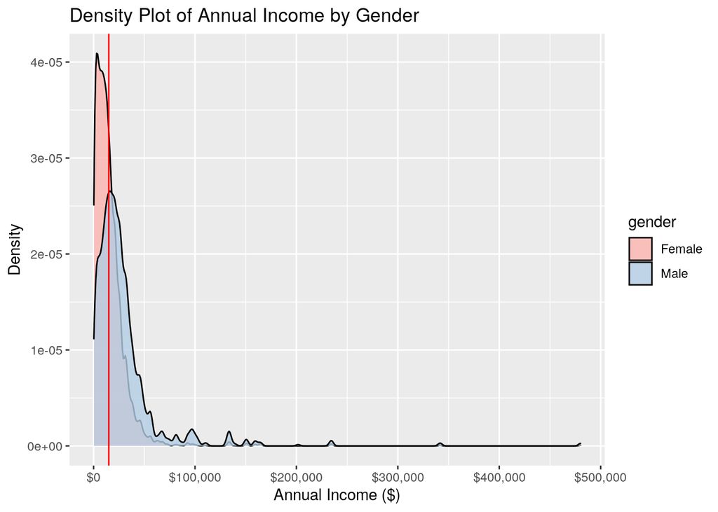

```r
# Plot 2

ggplot(fulldata, aes(x = realrinc, fill = gender)) + geom_density(alpha = 0.8) +
    labs(x = "Annual Income ($)", y = "Density") + ggtitle("Density Plot of Annual Income by Gender") +
    scale_fill_brewer(palette = "Pastel1") + geom_vline(aes(xintercept = 15000),
    color = "red") + scale_x_continuous(labels = scales::dollar)
```

Discussion of Plot 2

*Similar to histograms, density plots are used to visualize the distribution of a numeric variable, annual income in this case, by drawing appropriate continuous curves. This type of plot is useful for this data set because it contains many data points, which is allows for the density plot to be reliable and informative. For this data set, density plots have an advantage over histograms because we can use it to visualize the income distribution of both genders. The red line on the plot demonstrates the line of minimum wage using Texas as reference ($15,000). As shown above, there is a larger density of Females who are making less than minimum wage compared to the density of Males who are making less than minimum wage. Males are depicted to have a wider distribution towards higher income, while there is a low density of Females who are making high income. Conclusively, this density plot shows the relationship between gender and income, and further validate my earlier hypothesis that Males have higher income than Females.*

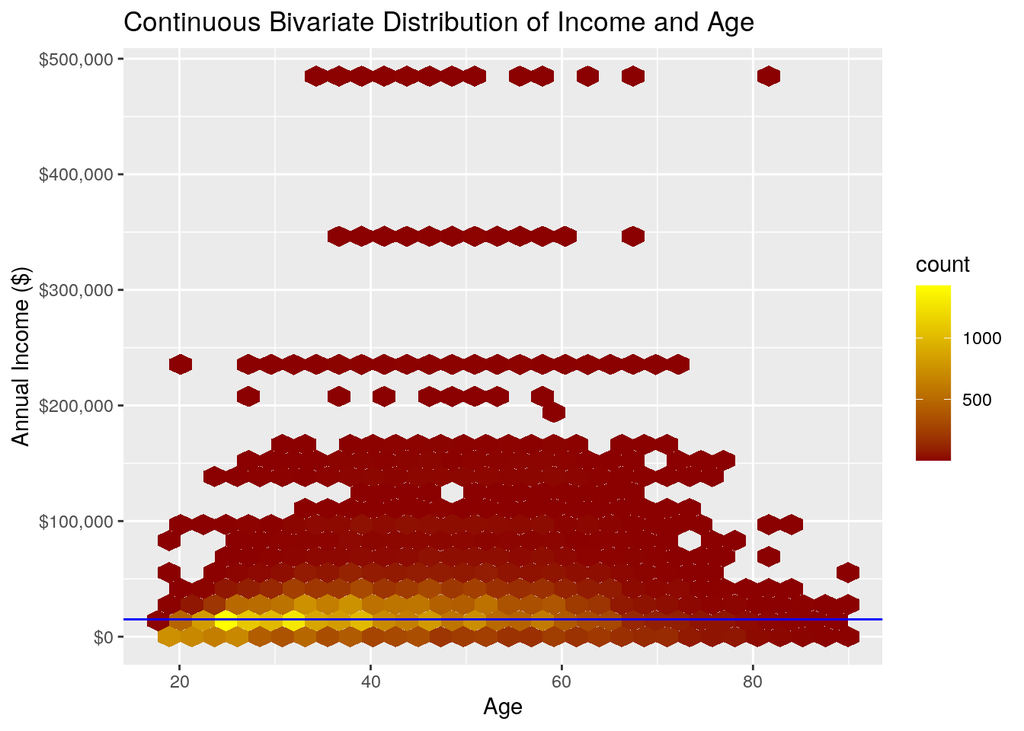

```r
# Plot 3

ggplot(fulldata, aes(age, realrinc)) + geom_hex() + scale_fill_gradient(low = "dark red",
    high = "yellow") + geom_hline(yintercept = c(15000), color = "blue") +
    labs(x = "Age", y = "Annual Income ($)") + ggtitle("Continuous Bivariate Distribution of Income and Age") +
    scale_y_continuous(labels = scales::dollar)
```

Discussion of Plot 3

*For this plot, I wanted to explore the continuous bivariate distribution between age and annual income. The blue line on the plot demonstrates the line of minimum wage using Texas as reference ($15,000). This heat map is helpful in visualizing the magnitude of the distributions as color in two dimensions. It is apparent in this plot that the majority of people who are making minimum wage and less are under the age of 40. The plot depicts only a small subset of people who earns more than $100,000 annually.*

#### Concluding Remarks

Conclusively, upon doing data wrangling, data exploration, and data visualization, I was able to further examine the informative relationships between the explanatory variables: gender, education status, age, and others with the response variable: annual income. The results from the data wrangling and data visualization demonstrated that gender, education status, and age has an effect on the annual income of individuals in this population from the study. My earlier hypothesis: there is a wage gap between genders with Males having higher income than Females: are supported by the results from the data exploration.